# TimeSeries

Dr. B

Sunday, April 12, 2015

```r
# Clear the environment
rm(list=ls())

# Turn off scientific notations for numbers
options(scipen = 999)

# Set locale
Sys.setlocale("LC_ALL", "English")
```

```
## [1] "LC_COLLATE=English_United States.1252;LC_CTYPE=English_United States.1252;LC_MONETARY=English_United States.1252;LC_NUMERIC=C;LC_TIME=English_United States.1252"
```

```r
# Set seed for reproducibility
set.seed(2345)

# load the libraries
library(forecast)
library(TTR)
```

January 1990 to April 2004.  
Air RPM per (000) Rail PM VMT (billions)

```r
# Load the data and make it into time series
air <- scan("D:/Data/911air.txt")
airtimeseries <- ts(air, frequency=12, start=c(1990,1))

rail <- scan("D:/Data/911rail.txt")
railtimeseries <- ts(rail, frequency=12, start=c(1990,1))

car <- scan("D:/Data/911car.txt")
cartimeseries <- ts(car, frequency=12, start=c(1990,1))
```

You plot the timeseries data:

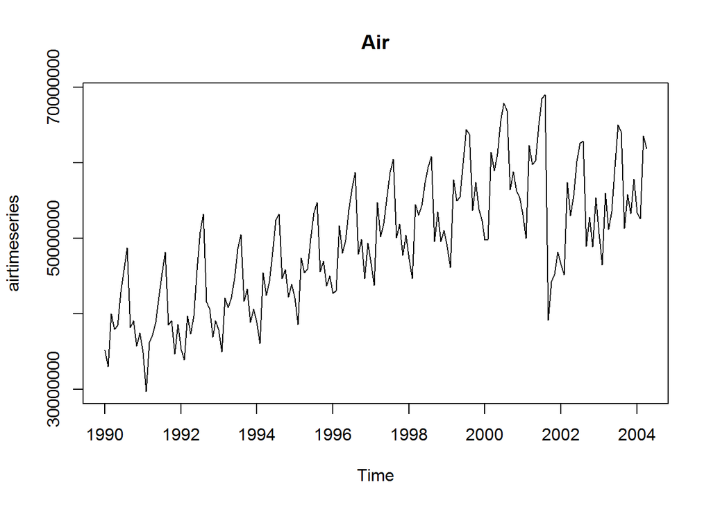

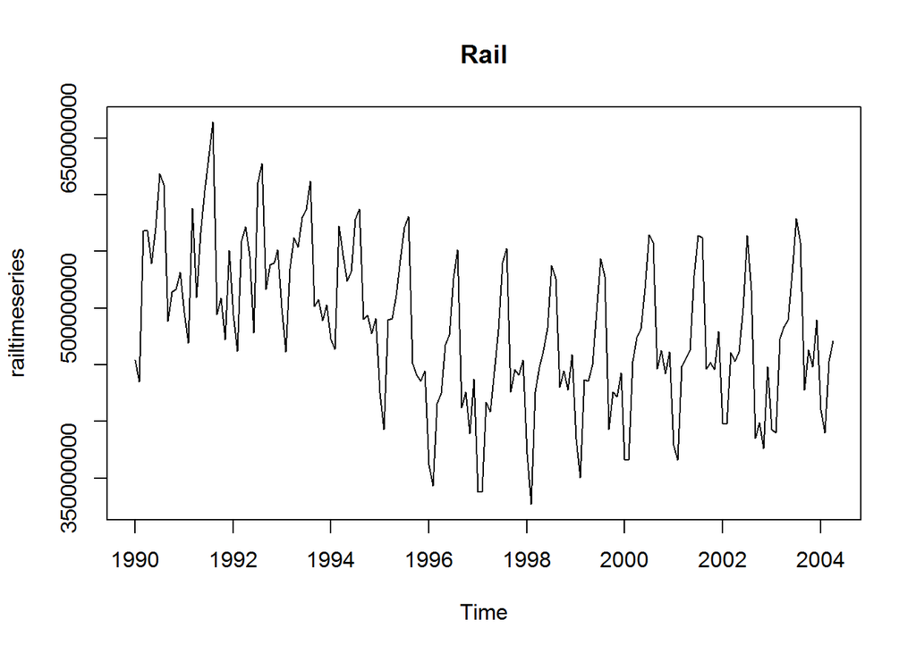

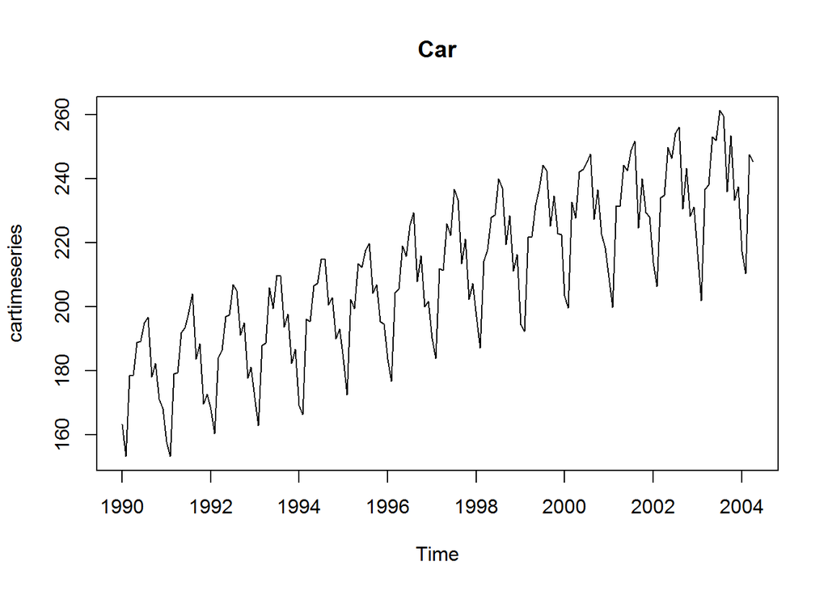

### Tramsforming data

When it appears that an additive model is not appropriate for describing a time series, such as when the size of the seasonal fluctuations and random fluctuations seem to increase with the level of the time series, we may need to transform the time series in order to get a transformed time series that can be described using an additive model.

For example, we can transform the time series by calculating the natural log of the original data:

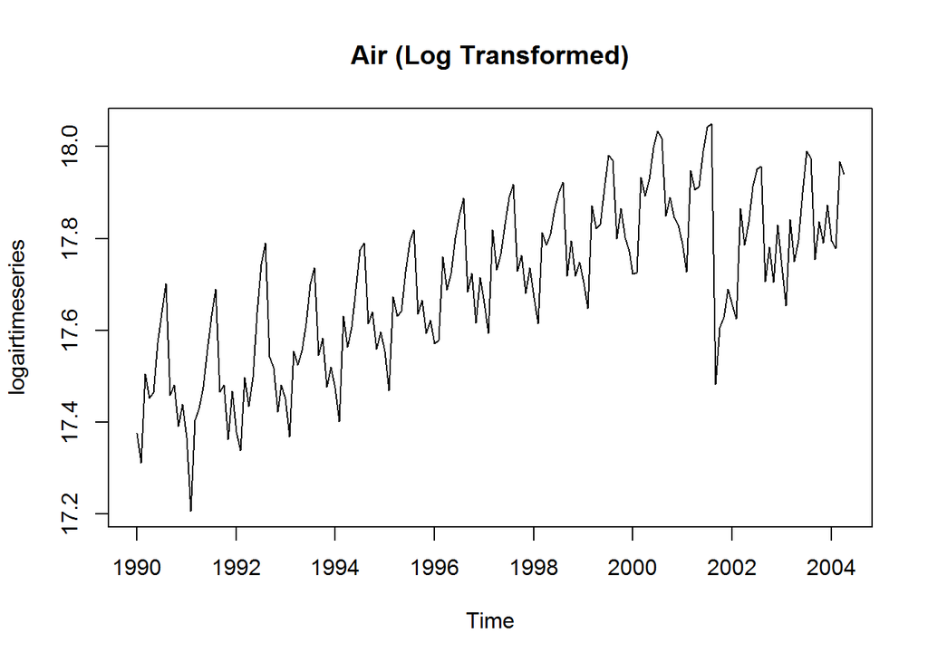

```r
logairtimeseries <- log(airtimeseries)
plot.ts(logairtimeseries, main="Air (Log Transformed)")
```

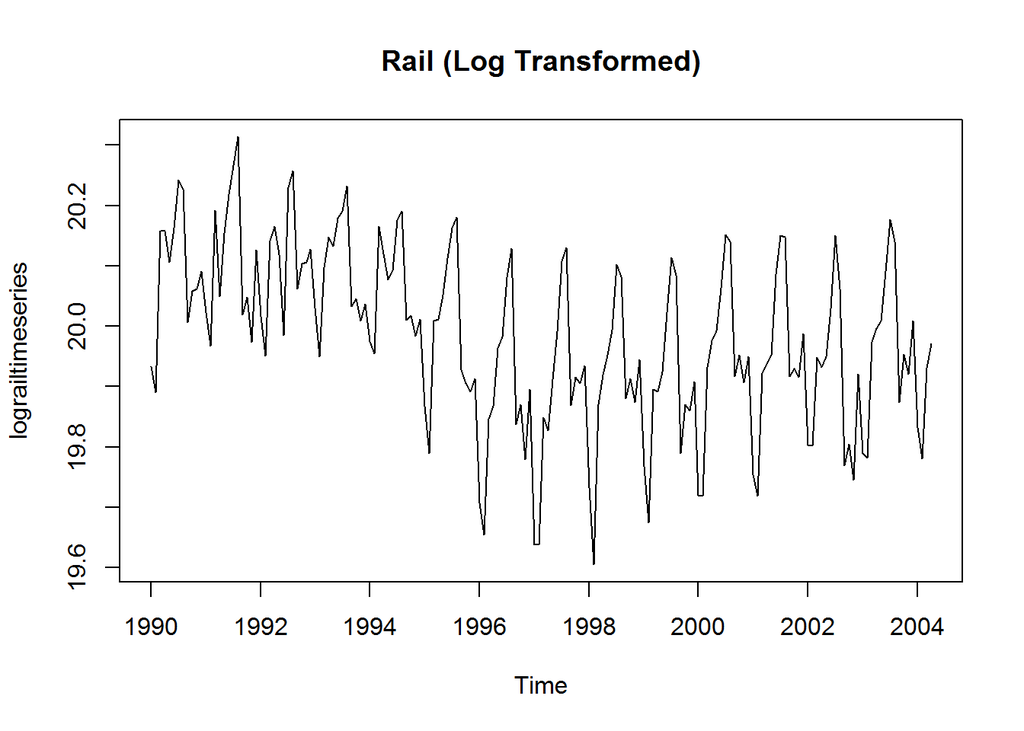

```r
lograiltimeseries <- log(railtimeseries)
plot.ts(lograiltimeseries, main="Rail (Log Transformed)")
```

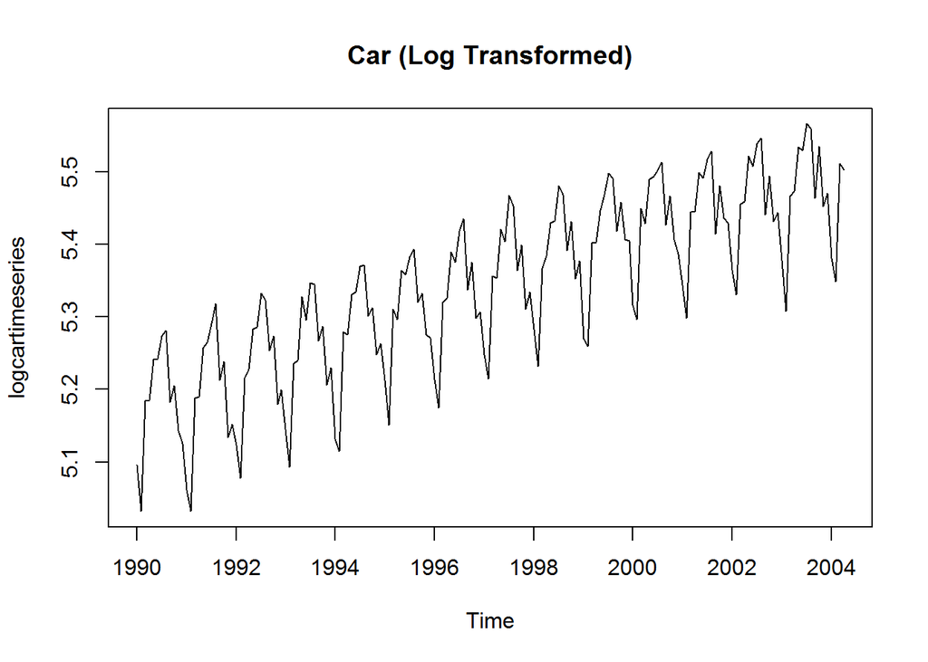

```r
logcartimeseries <- log(cartimeseries)
plot.ts(logcartimeseries, main="Car (Log Transformed)")
```

## Decomposing Time Series

Decomposing a time series means separating it into its various components, which are usually a trend component and an irregular component, and if it is a seasonal time series, a seasonal component.

### Decomposing Non-Seasonal Data

A non-seasonal time series consists of a trend component and an irregular component. Decomposing the time series involves trying to separate the time series into these components, that is, estimating the the trend component and the irregular component. To estimate the trend component of a non-seasonal time series that can be described using an additive model, it is common to use a smoothing method, such as calculating the simple moving average of the time series. The SMA() function in the “TTR” package can be used to smooth time series data using a simple moving average.

To use the SMA() function, you need to specify the order (span) of the simple moving average, using the parameter “n”. For example, to calculate a simple moving average of order 5, we set n=5 in the SMA() function.

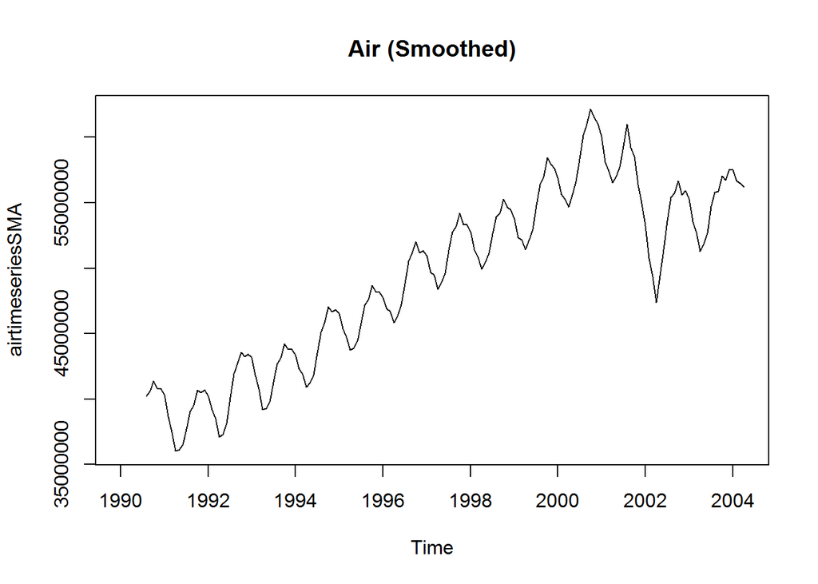

```r
#
n=8
airtimeseriesSMA <- SMA(airtimeseries,n=n)
railtimeseriesSMA <- SMA(railtimeseries,n=n)
cartimeseriesSMA <- SMA(cartimeseries,n=n)

plot.ts(airtimeseriesSMA, main="Air (Smoothed)")
```

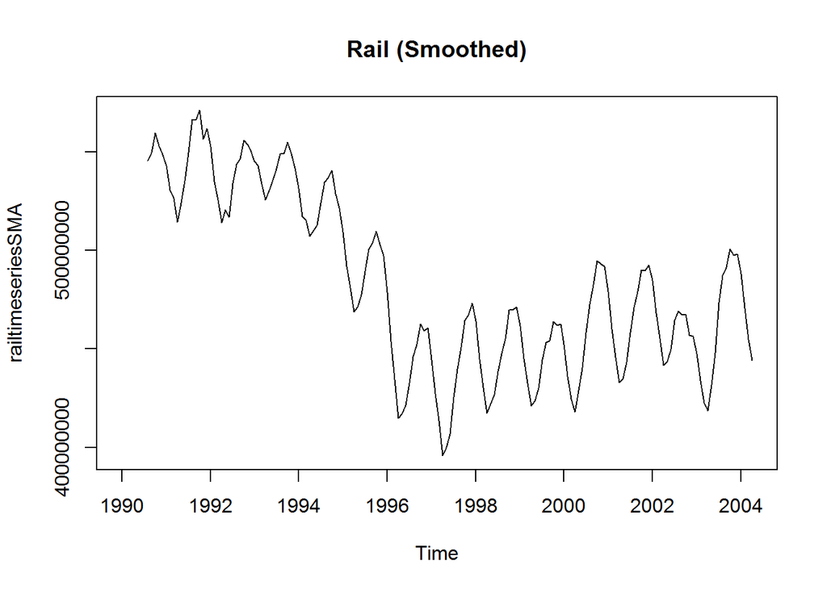

```r
plot.ts(railtimeseriesSMA, main="Rail (Smoothed)")
```

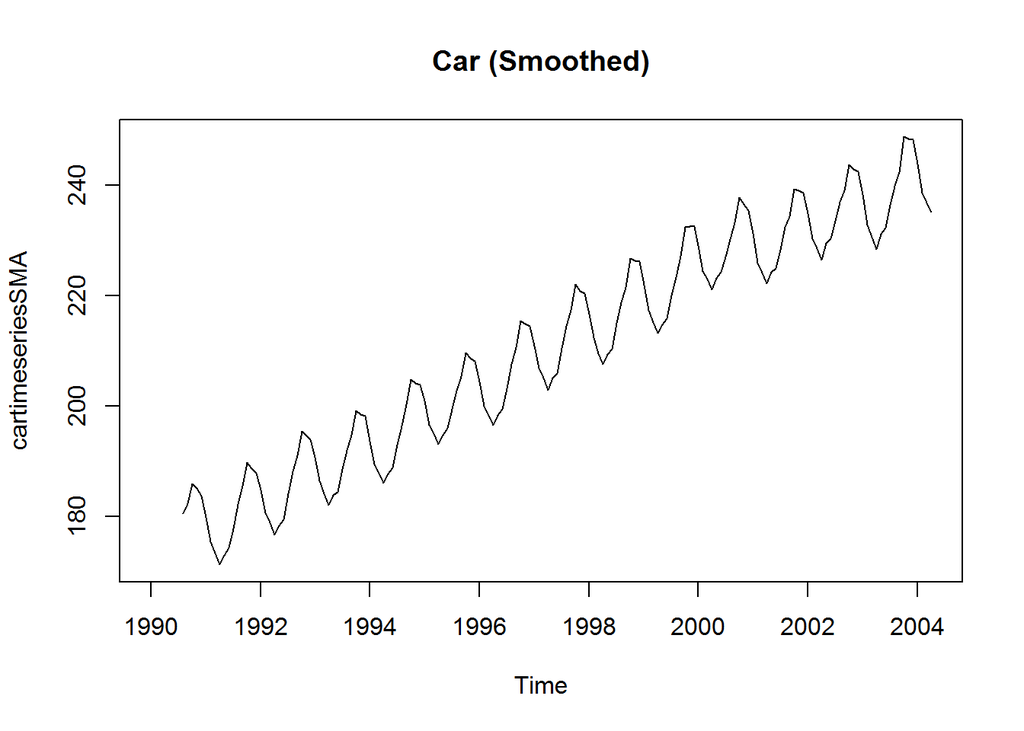

```r
plot.ts(cartimeseriesSMA, main="Car (Smoothed)")
```

### Decomposing Seasonal Data

A seasonal time series consists of a trend component, a seasonal component and an irregular component. Decomposing the time series means estimating these three components. To estimate the trend component and seasonal component of a seasonal time series that can be described using an additive model, we can use the “decompose()” function in R. This function estimates the trend, seasonal, and irregular components of a time series that can be described using an additive model.

The function “decompose()” returns a list object as its result, where the estimates of the seasonal component, trend component and irregular component are stored in named elements of that list objects, called “seasonal”, “trend”, and “random” respectively.

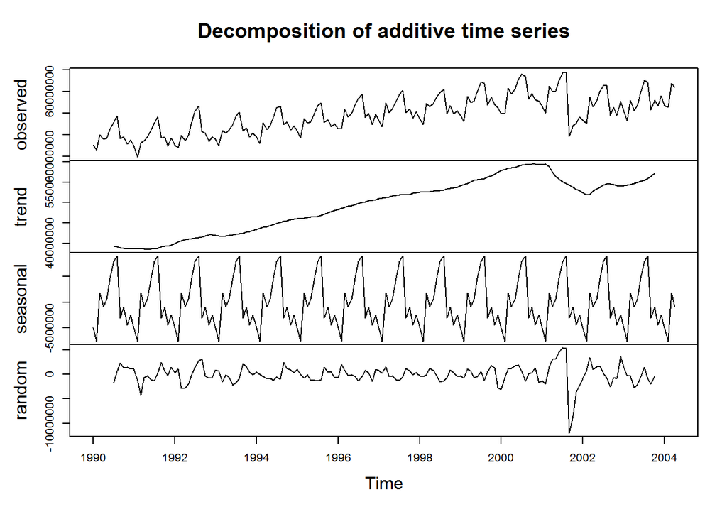

```r
#
airtimeseriescomponents <- decompose(airtimeseries)
railtimeseriescomponents <- decompose(railtimeseries)
cartimeseriescomponents <- decompose(cartimeseries)

plot(airtimeseriescomponents)
```

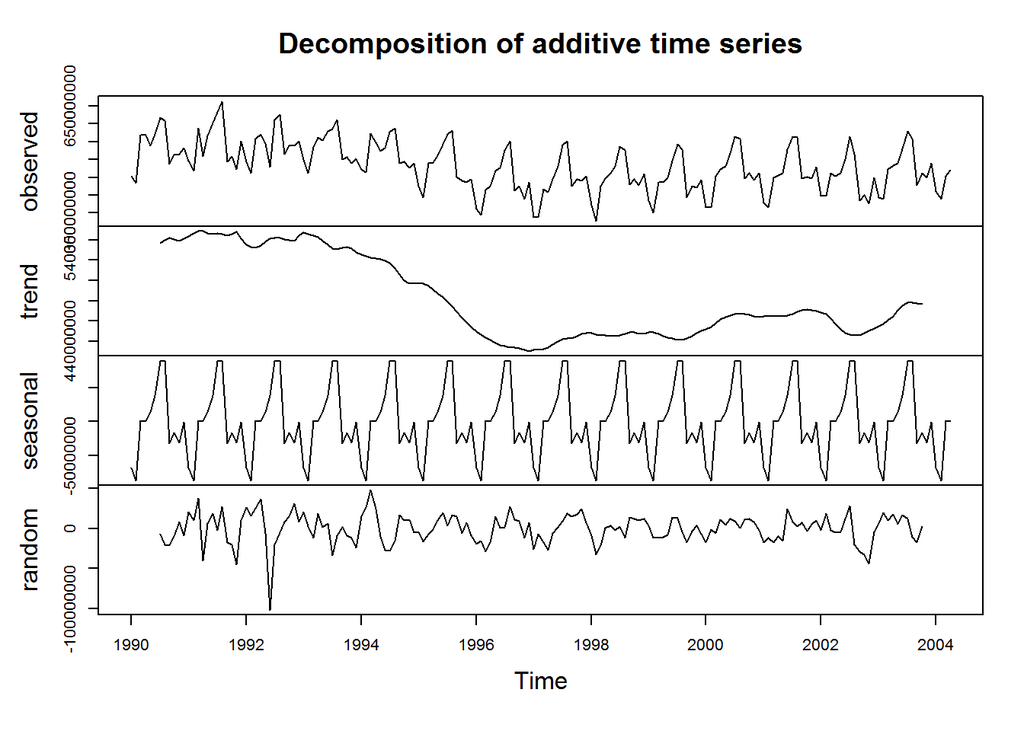

```r
plot(railtimeseriescomponents)
```

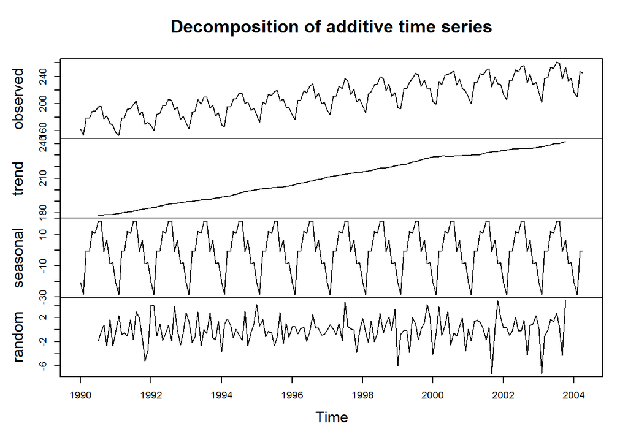

```r
plot(cartimeseriescomponents)
```

## Forecast

### ARIMA Model

```r
# fit an ARIMA(0,1,1) model
airtimeseriesarima <- arima(airtimeseries, order=c(0,1,1))
railtimeseriesarima <- arima(railtimeseries, order=c(0,1,1))
cartimeseriesarima <- arima(cartimeseries, order=c(0,1,1))
```

We can then use the ARIMA model to make forecasts for future values of the time series, using the “forecast.Arima()” function in the “forecast” R package.

```r
airtimeseriesforecasts <- forecast.Arima(airtimeseriesarima, h=19)
airtimeseriesforecasts
```

```
##          Point Forecast    Lo 80    Hi 80    Lo 95    Hi 95
## May 2004       61506898 54742660 68271136 51161888 71851907
## Jun 2004       61506898 53207619 69806176 48814246 74199549
## Jul 2004       61506898 51915175 71098620 46837624 76176171
## Aug 2004       61506898 50777301 72236494 45097395 77916400
## Sep 2004       61506898 49749034 73264761 43524797 79488998
## Oct 2004       61506898 48803730 74210065 42079079 80934716
## Nov 2004       61506898 47924056 75089739 40733734 82280061
## Dec 2004       61506898 47097988 75915808 39470371 83543424
## Jan 2005       61506898 46316776 76697019 38275611 84738184
## Feb 2005       61506898 45573822 77439973 37139361 85874434
## Mar 2005       61506898 44864001 78149794 36053783 86960012
## Apr 2005       61506898 44183240 78830556 35012649 88001146
## May 2005       61506898 43528237 79485558 34010909 89002886
## Jun 2005       61506898 42896273 80117522 33044403 89969392
## Jul 2005       61506898 42285075 80728720 32109657 90904138
## Aug 2005       61506898 41692722 81321074 31203730 91810065
## Sep 2005       61506898 41117570 81896225 30324112 92689683
## Oct 2005       61506898 40558203 82455592 29468635 93545161
## Nov 2005       61506898 40013389 83000406 28635413 94378382
```

```r
railtimeseriesforecasts <- forecast.Arima(railtimeseriesarima, h=19)
railtimeseriesforecasts
```

```
##          Point Forecast     Lo 80     Hi 80     Lo 95     Hi 95
## May 2004      463601814 392607425 534596203 355025266 572178362
## Jun 2004      463601814 374477296 552726332 327297627 599906001
## Jul 2004      463601814 359456934 567746694 304325965 622877663
## Aug 2004      463601814 346345119 580858509 284273175 642930453
## Sep 2004      463601814 334558764 592644864 266247499 660956129
## Oct 2004      463601814 323762316 603441312 249735757 677467871
## Nov 2004      463601814 313741674 613461954 234410508 692793121
## Dec 2004      463601814 304350321 622853307 220047673 707155955
## Jan 2005      463601814 295482766 631720862 206485917 720717711
## Feb 2005      463601814 287060060 640143568 193604501 733599127
## Mar 2005      463601814 279021297 648182331 181310274 745893354
## Apr 2005      463601814 271318316 655885312 169529581 757674047
## May 2005      463601814 263912255 663291373 158202988 769000640
## Jun 2005      463601814 256771216 670432412 147281711 779921918
## Jul 2005      463601814 249868633 677334995 136725121 790478507
## Aug 2005      463601814 243182102 684021526 126498955 800704673
## Sep 2005      463601814 236692525 690511104 116574003 810629626
## Oct 2005      463601814 230383457 696820171 106925116 820278512
## Nov 2005      463601814 224240626 702963002  97530467 829673161
```

```r
cartimeseriesforecasts <- forecast.Arima(cartimeseriesarima, h=20)
cartimeseriesforecasts
```

```
##          Point Forecast    Lo 80    Hi 80    Lo 95    Hi 95
## May 2004       244.5227 227.8477 261.1978 219.0205 270.0250
## Jun 2004       244.5227 223.0740 265.9715 211.7197 277.3258
## Jul 2004       244.5227 219.1842 269.8613 205.7708 283.2747
## Aug 2004       244.5227 215.8167 273.2288 200.6207 288.4248
## Sep 2004       244.5227 212.8048 276.2407 196.0143 293.0312
## Oct 2004       244.5227 210.0551 278.9904 191.8090 297.2365
## Nov 2004       244.5227 207.5090 281.5365 187.9152 301.1303
## Dec 2004       244.5227 205.1272 283.9183 184.2725 304.7730
## Jan 2005       244.5227 202.8814 286.1641 180.8378 308.2077
## Feb 2005       244.5227 200.7507 288.2948 177.5792 311.4663
## Mar 2005       244.5227 198.7190 290.3265 174.4719 314.5736
## Apr 2005       244.5227 196.7736 292.2719 171.4968 317.5487
## May 2005       244.5227 194.9045 294.1410 168.6382 320.4073
## Jun 2005       244.5227 193.1033 295.9422 165.8834 323.1621
## Jul 2005       244.5227 191.3630 297.6825 163.2220 325.8235
## Aug 2005       244.5227 189.6780 299.3675 160.6449 328.4006
## Sep 2005       244.5227 188.0432 301.0023 158.1447 330.9008
## Oct 2005       244.5227 186.4544 302.5911 155.7148 333.3307
## Nov 2005       244.5227 184.9079 304.1376 153.3497 335.6958
## Dec 2005       244.5227 183.4006 305.6449 151.0444 338.0011
```